# Case Study 4 - REST API Stock Market Predictions

Let's download some financial stock data from Kaggle's open data sources. The dataset holds stock market end-of-day prices and corollary data for stocks of the S&P 500 over a period of 5 years.

```python
import pandas as pd
import matplotlib.pyplot as plt
from pylab import rcParams
import matplotlib
import datetime, random
import numpy as np; np.random.seed(0)
import warnings
import itertools
import numpy as np
import pandas_datareader.data as web
warnings.filterwarnings('ignore')

# Load locally
local = False
if local:
    # read locally saved version
    stocks_df = pd.read_csv('all_stocks_5yr.csv')
else:
    # stock_data_file = 'data/sandp500/all_stocks_5yr.csv'
    # Load directly from GitHub from MLfinancetwi
    stock_data_file = 'https://raw.githubusercontent.com/amunategui/MLfinance/master/all_stocks_5yr.csv'
    stocks_df = pd.read_csv(stock_data_file, parse_dates=['Date'])
    # make a local copy
    stocks_df.columns = ['date', 'open', 'high', 'low', 'close', 'volume', 'Name']
    stocks_df.to_csv('all_stocks_5yr.csv', index=None)

stocks_df = stocks_df.sort_values('date')
stocks_df.head()
```

|  | date | open | high | low | close | volume | Name |
| --- | --- | --- | --- | --- | --- | --- | --- |
| 0 | 2012-08-13 | 92.29 | 92.59 | 91.74 | 92.40 | 2075391.0 | MMM |
| 304943 | 2012-08-13 | 18.12 | 18.31 | 17.83 | 18.19 | 1448045.0 | INCY |
| 513623 | 2012-08-13 | 41.69 | 41.94 | 41.45 | 41.79 | 1793206.0 | STT |
| 303685 | 2012-08-13 | 198.88 | 199.98 | 197.79 | 199.01 | 2418289.0 | IBM |
| 301478 | 2012-08-13 | 26.76 | 26.83 | 26.41 | 26.69 | 23623918.0 | INTC |

### Date ranges

```python
np.min(stocks_df['date'])
```

```
Timestamp('2012-08-13 00:00:00')
```

```python
np.max(stocks_df['date'])
```

```
Timestamp('2017-08-11 00:00:00')
```

### Size and description

```python
stocks_df.describe()
```

|  | open | high | low | close | volume |
| --- | --- | --- | --- | --- | --- |
| count | 606417.000000 | 606593.000000 | 606574.000000 | 606801.000000 | 6.063950e+05 |
| mean | 79.529041 | 80.257435 | 78.799338 | 79.557920 | 4.500925e+06 |
| std | 93.383162 | 94.187977 | 92.535300 | 93.382168 | 9.336171e+06 |
| min | 1.620000 | 1.690000 | 1.500000 | 1.590000 | 0.000000e+00 |
| 25% | 38.070000 | 38.460000 | 37.700000 | 38.090000 | 1.077091e+06 |
| 50% | 59.240000 | 59.790000 | 58.690000 | 59.270000 | 2.131913e+06 |
| 75% | 89.390000 | 90.150000 | 88.620000 | 89.430000 | 4.442768e+06 |
| max | 2044.000000 | 2067.990000 | 2035.110000 | 2049.000000 | 6.182376e+08 |

```python
stocks_df.shape
```

```
(606801, 7)
```

### Number of unique stock symbols

```python
print('Number of unique symbols:', len(set(stocks_df['Name'])))
```

```
Number of unique symbols: 503
```

### Just for fun, let's plot one of these

```
Text(0,0.5,'Price in $')
```

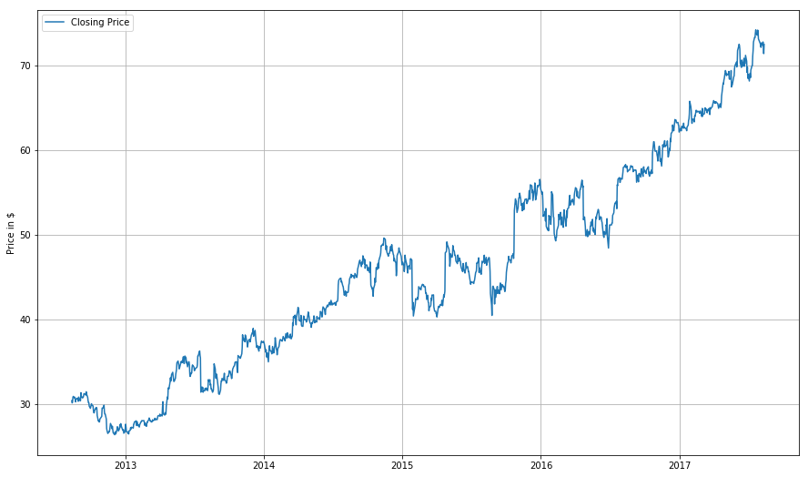

```python
fig, ax = plt.subplots(figsize=(15,9))
temp_df = stocks_df[stocks_df['Name']=='MSFT']

ax.plot(pd.to_datetime(temp_df['date']), temp_df['close'], label='Closing Price')
ax.grid()
ax.legend(loc='best')
ax.set_ylabel('Price in $')
```

## Prepare the stock market data

Let's use 10 periods of trading market and predict 5 days out (and please experiment with those settings as that’s half the fun). This is time-series data so we are going to take consecutive segments for each stock to use as features. This means we are going to take every closing price, tie the previous 10 closing prices for that stock and add them as features to the row. This will allow each row to capture some of the price movement over the past couple of trading periods.

The idea behind this approach is based on trend following. There is a higher probability that if today is an up-day, tomorrow will be an up day as well. So here we’ll give the model 10 days to learn what is the overall direction of the market and predict accordingly.

We will also help out the model and normalize the prices by applying the log transform on all of them (we will have to translate it back when presenting data to the customer).

Running this portion of the code takes a couple of minutes, so be patient as it has to perform this on 500 individual stocks.

### Note: Log Transform

Let's help the model by normalizing the price data using log transform (we will have to translate it back when presenting data to the customer).

Let's look at one stock to understand the transformation:

```python
stock_data = stocks_df[stocks_df['Name']=='MSFT'].copy()
stock_data[['date', 'close', 'Name']].head(20)
```

|  | date | close | Name |
| --- | --- | --- | --- |
| 380416 | 2012-08-13 | 30.39 | MSFT |
| 380417 | 2012-08-14 | 30.13 | MSFT |
| 380418 | 2012-08-15 | 30.20 | MSFT |
| 380419 | 2012-08-16 | 30.78 | MSFT |
| 380420 | 2012-08-17 | 30.90 | MSFT |
| 380421 | 2012-08-20 | 30.74 | MSFT |
| 380422 | 2012-08-21 | 30.80 | MSFT |
| 380423 | 2012-08-22 | 30.54 | MSFT |
| 380424 | 2012-08-23 | 30.26 | MSFT |
| 380425 | 2012-08-24 | 30.56 | MSFT |
| 380426 | 2012-08-27 | 30.69 | MSFT |
| 380427 | 2012-08-28 | 30.63 | MSFT |
| 380428 | 2012-08-29 | 30.65 | MSFT |
| 380429 | 2012-08-30 | 30.32 | MSFT |
| 380430 | 2012-08-31 | 30.82 | MSFT |
| 380431 | 2012-09-04 | 30.38 | MSFT |
| 380432 | 2012-09-05 | 30.39 | MSFT |
| 380433 | 2012-09-06 | 31.34 | MSFT |
| 380434 | 2012-09-07 | 30.95 | MSFT |
| 380435 | 2012-09-10 | 30.72 | MSFT |

```python
stock_symbols = list(set(stocks_df['Name']))

# build dataset
X = []
y = []
symbols = []
prediction_dates = []
last_market_dates = []

# rolling predictions
rolling_period = 10
predict_out_period = 5

for stock in stock_symbols:
    print(stock)
    stock_data = stocks_df[stocks_df['Name']==stock].copy()

    for per in range(rolling_period, len(stock_data)-predict_out_period):
        X_tmp = []
        y_tmp = 0
        for rollper in range(per-rolling_period,per):
            # build the 'features'
            X_tmp += [np.log(stock_data['close'].values[rollper])]

        X.append(np.array(X_tmp))
        # build 'labels'
        y.append(np.log(stock_data['close'].values[per + predict_out_period]))
        prediction_dates.append(stock_data['date'].values[per + predict_out_period])
        last_market_dates.append(stock_data['date'].values[per])
        symbols.append(stock)
```

[output not shown]

[output cut: 448 more lines]

[output not shown]

### Package it all into a neat dataframe

```python
stock_model_ready_df = pd.DataFrame(X)
stock_model_ready_df.columns = [str(f) for f in list(stock_model_ready_df)]

stock_model_ready_df['outcome'] = y
stock_model_ready_df['prediction_date'] = prediction_dates
stock_model_ready_df['last_market_date'] = last_market_dates
stock_model_ready_df['symbol'] = symbols
stock_model_ready_df.tail()
```

|  | 0 | 1 | 2 | 3 | 4 | 5 | 6 | 7 | 8 | 9 | outcome | prediction_date | last_market_date | symbol |
| --- | --- | --- | --- | --- | --- | --- | --- | --- | --- | --- | --- | --- | --- | --- |
| 599251 | 3.813969 | 3.809769 | 3.842030 | 3.839667 | 3.841386 | 3.843958 | 3.863043 | 3.854606 | 3.852061 | 3.842887 | 3.877639 | 2017-08-07 | 2017-07-31 | MS |
| 599252 | 3.809769 | 3.842030 | 3.839667 | 3.841386 | 3.843958 | 3.863043 | 3.854606 | 3.852061 | 3.842887 | 3.848018 | 3.869742 | 2017-08-08 | 2017-08-01 | MS |
| 599253 | 3.842030 | 3.839667 | 3.841386 | 3.843958 | 3.863043 | 3.854606 | 3.852061 | 3.842887 | 3.848018 | 3.854606 | 3.863883 | 2017-08-09 | 2017-08-02 | MS |
| 599254 | 3.839667 | 3.841386 | 3.843958 | 3.863043 | 3.854606 | 3.852061 | 3.842887 | 3.848018 | 3.854606 | 3.857144 | 3.835142 | 2017-08-10 | 2017-08-03 | MS |
| 599255 | 3.841386 | 3.843958 | 3.863043 | 3.854606 | 3.852061 | 3.842887 | 3.848018 | 3.854606 | 3.857144 | 3.855664 | 3.821004 | 2017-08-11 | 2017-08-04 | MS |

Now you will notice tha we have one row per market date (last_market_date) made up of a sequence of 10 periods of trading prices. It also has the x periods out prediction (i.e. the our outcome variable) and the date of the prediction along with the symbol.

```python
stock_model_ready_df.head()
```

|  | 0 | 1 | 2 | 3 | 4 | 5 | 6 | 7 | 8 | 9 | outcome | prediction_date | last_market_date | symbol |
| --- | --- | --- | --- | --- | --- | --- | --- | --- | --- | --- | --- | --- | --- | --- |
| 0 | 3.901164 | 3.875359 | 3.874321 | 3.877432 | 3.886910 | 3.888550 | 3.894673 | 3.892024 | 3.884652 | 3.886705 | 3.925334 | 2012-09-04 | 2012-08-27 | IT |
| 1 | 3.875359 | 3.874321 | 3.877432 | 3.886910 | 3.888550 | 3.894673 | 3.892024 | 3.884652 | 3.886705 | 3.894877 | 3.932022 | 2012-09-05 | 2012-08-28 | IT |
| 2 | 3.874321 | 3.877432 | 3.886910 | 3.888550 | 3.894673 | 3.892024 | 3.884652 | 3.886705 | 3.894877 | 3.905401 | 3.931630 | 2012-09-06 | 2012-08-29 | IT |
| 3 | 3.877432 | 3.886910 | 3.888550 | 3.894673 | 3.892024 | 3.884652 | 3.886705 | 3.894877 | 3.905401 | 3.909821 | 3.890186 | 2012-09-07 | 2012-08-30 | IT |
| 4 | 3.886910 | 3.888550 | 3.894673 | 3.892024 | 3.884652 | 3.886705 | 3.894877 | 3.905401 | 3.909821 | 3.897924 | 3.898938 | 2012-09-10 | 2012-08-31 | IT |

## Splitting the Data in to Train, Test, and Validation Portions

As with most modeling projects, we need to split our data into different portions: a training, a testing and a validation set. By doing this, we can use one portion toteach the model how to predict the stock market, the other portion to evaluate the model, and we’ll keep all the data for one single stock as a validation set and to plot the actual versus predicted - visuals are always good for your stakeholders.

### Two Approaches to Splitting Data

#### Option 1: Random Splits

The “train_test_split()” function from “sklearn” is great as it does most of that for us. Setting the seed (random_state) is paramount for reproducibility as thefunction will shuffle the data randomly before splitting it. But by using the same seed you will always get the same split in subsequent runs.

#### Option 2: Split By Date

There isn’t a one-size-fits-all, in some cases, it is good to split randomly, in others, where the time element can be intersting, then splitting it by time chunks can be useful. The code below does both, so please experiment a lot!

We also create a validation data set by taking out all data for a particular stock symbol and we’ll use the model to predict ever day for that stock and plot the predictions with an overlay of the actual price. Visuals! A visual makes for a thousand words…

```python
from sklearn.model_selection import train_test_split

TARGET = 'outcome'
FEATURES = [f for f in list(stock_model_ready_df) if f not in [TARGET, 'prediction_date', 'last_market_date', 'symbol']]

# keep on stock for out of sample testing - you can change this to your
# favorite stock
oos_stock ='MMM'
oos_stock_df = stock_model_ready_df[stock_model_ready_df['symbol']==oos_stock]
print('live excluded test data:', oos_stock_df.shape)
stock_model_ready_df = stock_model_ready_df[stock_model_ready_df['symbol']!=oos_stock]

# write a copy to file to use in our web application
# PythonAnywhere has a 100MB cap on files so we're going to truncate the file a bit
stock_model_ready_df.tail(400000).to_csv('stock_model_ready.csv', index=None)

# time based split or random?
TIME_BASED = True
if TIME_BASED:
    # date split
    date_split = '2017-01-01'
    x_train = stock_model_ready_df[stock_model_ready_df['last_market_date'] <= date_split]
    x_test = stock_model_ready_df[stock_model_ready_df['last_market_date'] > date_split]

    # shuffle training data
    x_train = x_train.sample(len(x_train))
    y_train = x_train[TARGET]
    y_test = x_test[TARGET]
else:
    x_train, x_test, y_train, y_test = train_test_split(stock_model_ready_df,
                                 stock_model_ready_df[TARGET], test_size=0.33, random_state=42)

print('x_train.shape:', x_train.shape)
print('x_test.shape:', x_test.shape)
```

```
live excluded test data: (1243, 14)
x_train.shape: (523576, 14)
x_test.shape: (74437, 14)
```

### Let's Learn About the Stock Market Using XGBoost

XGBoost is a phenomenal model. It can do classification, regression, multi-class classification, and more. It is one of the top models on Kaggle.com as it keeps on winning competitions! It runs on all sorts of programming languages - Julia, R, Python… For plenty more details about this incredible model, see the official docs at: https://xgboost.readthedocs.io/en/latest/

Anyway, it’s a great and fast model, perfect for our needs here.

```python
import xgboost as xgb

dtrain = xgb.DMatrix(data = x_train[FEATURES],  label = y_train)
dval = xgb.DMatrix(data = x_test[FEATURES], label = y_test)

param = {'max_depth':3,
            'eta':0.05,
            'silent':0,
            "objective":"reg:linear",
            "eval_metric":"rmse",
            'subsample': 0.8,
            'maximize': False,
            'colsample_bytree': 0.8}

evals = [(dtrain,'train'),(dval,'eval')]
stock_model = xgb.train ( params = param,
              dtrain = dtrain,
              num_boost_round = 1000,
              verbose_eval=50,
              early_stopping_rounds = 500,
              evals=evals)
```

[output not shown]

XGBoost requires the data be cast to its DMatrix format. You can also break out model parameters into a dictionary to keep things organized and readable. Check out the documentation for more details on the parameters - the important ones to tweak are “max_depth” and “eta”.

Anyway, we can then run the handy “get_fscore” function that will order out the most important features first. It is interesting that the first one listed is that last value, i.e. the most current in the sequence.

## Check out which features were the most valuable

```python
importances = stock_model.get_fscore()

importance_frame = pd.DataFrame({'Importance': list(importances.values()), 'Feature': list(importances.keys())})
importance_frame.sort_values(by = 'Importance', inplace = True, ascending= False)
importance_frame
```

|  | Feature | Importance |
| --- | --- | --- |
| 0 | 9 | 1396 |
| 5 | 0 | 822 |
| 1 | 8 | 694 |
| 9 | 1 | 501 |
| 8 | 2 | 411 |
| 6 | 3 | 393 |
| 3 | 5 | 376 |
| 7 | 4 | 361 |
| 2 | 7 | 333 |
| 4 | 6 | 332 |

## Evaluate the model

Books have been written on evaluating models. Here, we’ll take a shortcut and simply apply the model on our validation data (that’s the stock we earmarked purposely for visual evaluation) and plot the predictions against the actual values for comparison (which makes for a fantastic chart).

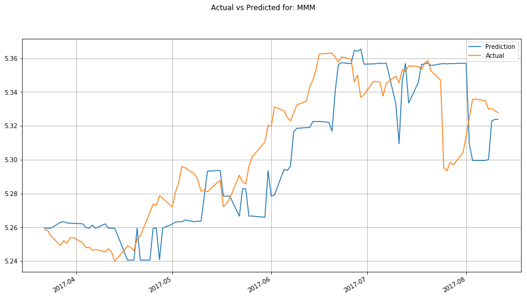

```python
# evaluate on one stock only for clarity
tmp_df = oos_stock_df.tail(100)
doos = xgb.DMatrix(data = tmp_df[FEATURES],  label = tmp_df[TARGET])

# predictions
preds = stock_model.predict(doos)

# get accuracy of score
fig, ax = plt.subplots(figsize=(15,8))
plt.plot(pd.to_datetime(tmp_df['prediction_date']), list(preds), label='Prediction')
plt.plot(pd.to_datetime(tmp_df['prediction_date']), list(tmp_df[TARGET]), label='Actual')
plt.legend()
plt.suptitle('Actual vs Predicted for: ' + oos_stock)
plt.grid()
plt.xticks(rotation='vertical')
ax.xaxis_date()
fig.autofmt_xdate()
plt.show()
```

Not too bad, right? Would I trade on these signals? Definitely not. Keep in mind that the scaling is still the log transform and in order to show this to web viewers, we will need to take the exponent to translate it back to normal dollar scale.

Also, again, this is only a toy project so don’t trade this!

## Good Enough, but How About Testing This on Live Data?

We will use the trusted (but experimental) Pandas function “pandas_datareader.data” that will pull data from the web site https://robinhood.com/. Let’s take a quick look at the data:

```python
import datetime
symbol='MSFT'
import pandas_datareader.data as web
end = datetime.datetime.now()
start = datetime.datetime.now() - datetime.timedelta(days=60)
live_stock_data = web.DataReader(symbol, 'robinhood', start, end)
live_stock_data.reset_index(inplace=True)
live_stock_data.tail()
```

|  | symbol | begins_at | close_price | high_price | interpolated | low_price | open_price | session | volume |
| --- | --- | --- | --- | --- | --- | --- | --- | --- | --- |
| 247 | MSFT | 2018-12-03 | 112.090000 | 113.420000 | False | 110.730000 | 113.000000 | reg | 34732772 |
| 248 | MSFT | 2018-12-04 | 108.520000 | 112.637300 | False | 108.211500 | 111.940000 | reg | 45196984 |
| 249 | MSFT | 2018-12-05 | 108.520000 | 108.520000 | True | 108.520000 | 108.520000 | reg | 0 |
| 250 | MSFT | 2018-12-06 | 109.190000 | 109.240000 | False | 105.000000 | 105.820000 | reg | 49107431 |
| 251 | MSFT | 2018-12-07 | 104.820000 | 109.450000 | False | 104.300000 | 108.380000 | reg | 45044937 |

Let’s determine what we need to do to get in the same format as the training data. Let’s start by dropping and renaming some of the columns.

We also need to apply the log transform of the closing price, and add the timeseries features.

```python
# prepare the live data for forecasting - log tranform it
live_stock_data = live_stock_data[['symbol', 'begins_at', 'close_price']]
live_stock_data.columns = ['symbol', 'date', 'close']

# make data model ready
live_stock_data['close'] = pd.to_numeric(live_stock_data['close'], errors='coerce')
live_stock_data['close'] = np.log(live_stock_data['close'])

# sort by ascending dates as we've done in training
live_stock_data = live_stock_data.sort_values('date')
```

Same concept as before except know we only want to keep the last row, the most current market sequence and pedict x days out.

```python
# build dataset
X = []
y = []

prediction_dates = []
last_market_dates = []

# rolling predictions
rolling_period = 10
predict_out_period = 5

for per in range(rolling_period, len(live_stock_data)):
    X_tmp = []
    y_tmp = 0
    for rollper in range(per-rolling_period,per):
        # build the 'features'
        X_tmp += [live_stock_data['close'].values[rollper]]

    X.append(np.array(X_tmp))

    # add x days to last market date using numpy timedelta64
    prediction_dates.append(live_stock_data['date'].values[per] + np.timedelta64(predict_out_period,'D'))
    last_market_dates.append(live_stock_data['date'].values[per])


live_stock_ready_df = pd.DataFrame(X)
live_stock_ready_df.columns = [str(f) for f in list(live_stock_ready_df)]

live_stock_ready_df['prediction_date'] = prediction_dates
live_stock_ready_df['last_market_date'] = last_market_dates

# we only want the latest row as we want to predict as far out as possible into the future
#live_stock_ready_df = live_stock_ready_df.tail()
```

```python
live_stock_ready_df.tail()
```

|  | 0 | 1 | 2 | 3 | 4 | 5 | 6 | 7 | 8 | 9 | prediction_date | last_market_date |
| --- | --- | --- | --- | --- | --- | --- | --- | --- | --- | --- | --- | --- |
| 237 | 4.684813 | 4.650335 | 4.622126 | 4.635796 | 4.635408 | 4.667863 | 4.674136 | 4.710611 | 4.702206 | 4.708539 | 2018-12-08 | 2018-12-03 |
| 238 | 4.650335 | 4.622126 | 4.635796 | 4.635408 | 4.667863 | 4.674136 | 4.710611 | 4.702206 | 4.708539 | 4.719302 | 2018-12-09 | 2018-12-04 |
| 239 | 4.622126 | 4.635796 | 4.635408 | 4.667863 | 4.674136 | 4.710611 | 4.702206 | 4.708539 | 4.719302 | 4.686934 | 2018-12-10 | 2018-12-05 |
| 240 | 4.635796 | 4.635408 | 4.667863 | 4.674136 | 4.710611 | 4.702206 | 4.708539 | 4.719302 | 4.686934 | 4.686934 | 2018-12-11 | 2018-12-06 |
| 241 | 4.635408 | 4.667863 | 4.674136 | 4.710611 | 4.702206 | 4.708539 | 4.719302 | 4.686934 | 4.686934 | 4.693089 | 2018-12-12 | 2018-12-07 |

```python
# create time-series feature engineering
doos = xgb.DMatrix(data = live_stock_ready_df[FEATURES])
# predictions
preds = stock_model.predict(doos)
preds[(len(preds)-10):len(preds)]
```

```
array([4.635602 , 4.650081 , 4.675467 , 4.699864 , 4.700596 , 4.7117414,
       4.7173867, 4.6889653, 4.6849513, 4.6962857], dtype=float32)
```

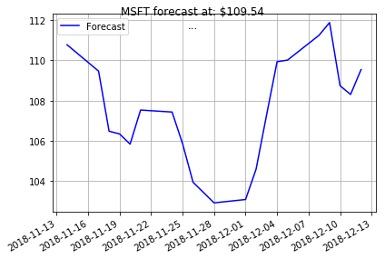

```python
future_df_tmp = live_stock_ready_df.copy()
future_df_tmp['forcast'] = np.exp(list(preds))
# just need a couple of rows
future_df_tmp = future_df_tmp.tail(20)

future_df_tmp = future_df_tmp.sort_values('prediction_date')
fig, axes = plt.subplots()
plt.suptitle(symbol + ' forecast at: $'+ str(np.round(future_df_tmp['forcast'].values[-1],2)) + '\n' + '...')
plt.plot(pd.to_datetime(future_df_tmp['prediction_date'].astype(str)), future_df_tmp['forcast'], color='blue', label='Forecast')
plt.legend()
plt.grid()
plt.xticks(rotation='vertical')
ax.xaxis_date()
fig.autofmt_xdate()
fig.tight_layout()
plt.show()
```

## Abstracting our forecasting code into a function

Remember, we don't need to build charts and a UI, we just want to a sybmol and return the prediction via our Rest API function.

The Restful API (or REST API) is based on the representational state transfer architecture, a definition of data interoperability over the Internet using web services. In simple terms, it uses a set of commands such as get, post, delete, update, etc. and passes the data over the internet atop the HTTP protocol. This allows it to piggyback over an existing technology normally used to generate web pages. This technology can be very useful to abstract complex processing away from a web application's code. It can even allow you to bring in advanced predictive analytics and machine learining into simple sites like GitHub.io Pages or WordPress pages.

Install the flask-restful library by running the below command in your terminal window. This Flask extension will abstract a lot of of the coding and best practices for our REST API for us (such creating classes and adding resource API end points).

```
    $ pip3 install flask-restful
```

Install the free version of [Postman at getpostman.com](https://www.getpostman.com/). This tool allows you to easily test your API points and a whole lot more.

Let's start by abstracting our function to take a stock symbol and return a predict price x days in the future.

```python
def GetTrainedModel(stock_model_ready_df, TARGET):
    FEATURES = [f for f in list(stock_model_ready_df) if f not in
                [TARGET, 'prediction_date', 'last_market_date', 'symbol']]

    x_train, x_test, y_train, y_test = train_test_split(stock_model_ready_df,
                                     stock_model_ready_df[TARGET], test_size=0.33, random_state=42)

    dtrain = xgb.DMatrix(data = x_train[FEATURES],  label = y_train)
    dval = xgb.DMatrix(data = x_test[FEATURES], label = y_test)

    param = {'max_depth':3,
                'eta':0.05,
                'silent':0,
                "objective":"reg:linear",
                "eval_metric":"rmse",
                'subsample': 0.8,
                'maximize': False,
                'colsample_bytree': 0.8}

    evals = [(dtrain,'train'),(dval,'eval')]
    stock_model = xgb.train ( params = param,
                  dtrain = dtrain,
                  num_boost_round = 500,
                  verbose_eval=50,
                  early_stopping_rounds = 500,
                  evals=evals)
    return(stock_model, FEATURES)

def GetLiveStockData(symbol, size=50):
    # we'll use pandas_datareader
    import datetime
    pd.core.common.is_list_like = pd.api.types.is_list_like
    import pandas_datareader.data as web

    try:
        end = datetime.datetime.now()
        start = datetime.datetime.now() - datetime.timedelta(days=60)
        live_stock_data = web.DataReader(symbol, 'robinhood', start, end)
        live_stock_data.reset_index(inplace=True)
        live_stock_data = live_stock_data[['symbol', 'begins_at', 'close_price']]
        live_stock_data.columns = ['symbol', 'date', 'close']
    except:
        live_stock_data = None

    if (live_stock_data is not None):
        live_stock_data = live_stock_data.sort_values('date')
        live_stock_data = live_stock_data.tail(size)

        # make data model ready
        live_stock_data['close'] = pd.to_numeric(live_stock_data['close'], errors='coerce')
        live_stock_data['close'] = np.log(live_stock_data['close'])

        # clean up the data so it aligns with our earlier notation
        #live_stock_data['date'] = pd.to_datetime(live_stock_data['date'], format = '%m/%d/%y')
        # sort by ascending dates as we've done in training
        live_stock_data = live_stock_data.sort_values('date')

        # build dataset
        X = []

        prediction_dates = []
        last_market_dates = []

        # rolling predictions
        rolling_period = 10
        predict_out_period = 5

        for per in range(rolling_period, len(live_stock_data)):
            X_tmp = []
            for rollper in range(per-rolling_period,per):
                # build the 'features'
                X_tmp += [live_stock_data['close'].values[rollper]]

            X.append(np.array(X_tmp))

            # add x days to last market date using numpy timedelta64
            prediction_dates.append(live_stock_data['date'].values[per] + np.timedelta64(predict_out_period,'D'))
            last_market_dates.append(live_stock_data['date'].values[per])


        live_stock_ready_df = pd.DataFrame(X)
        live_stock_ready_df.columns = [str(f) for f in list(live_stock_ready_df)]

        live_stock_ready_df['prediction_date'] = prediction_dates
        live_stock_ready_df['last_market_date'] = last_market_dates

        live_stock_ready_df.columns = [str(f) for f in live_stock_ready_df]

        return(live_stock_ready_df)
    else:
        return(None)


def GetPrediction(symbol, stock_df, xgb_model, FEATURES):
    # create time-series feature engineering
    doos = xgb.DMatrix(data = stock_df[FEATURES])
    # predictions
    preds = xgb_model.predict(doos)

    # just pull las 10 preds and build chart
    future_df_tmp = stock_df.copy()
    future_df_tmp['forcast'] = np.exp(list(preds))

    # just need a couple of rows
    future_df_tmp = future_df_tmp.tail(20)
    future_df_tmp = future_df_tmp.sort_values('prediction_date')

    return(future_df_tmp)




# load model-ready data
import xgboost as xgb
stock_model_ready_df = pd.read_csv('stock_model_ready.csv')
# set all features to strings
stock_model_ready_df.columns = [str(f) for f in list(stock_model_ready_df)]

# train the xgb model whenever the server is reset
# You could also train the model in advance and load the saved version up to skip this step
xgb_stock_model, FEATURES = GetTrainedModel(stock_model_ready_df, TARGET='outcome')

get_financial_information('MSFT')
```

```
Multiple eval metrics have been passed: 'eval-rmse' will be used for early stopping.

Will train until eval-rmse hasn't improved in 500 rounds.
```

```python
def get_financial_information(selected_stock):
    selected_stock = selected_stock.upper()
    predicted_price = -999

    if (len(selected_stock) > 0):
        # get latest data
        stock_df = GetLiveStockData(selected_stock)
        if (stock_df is not None):
            if len(stock_df) > 0:
                predicted_price = GetPrediction(selected_stock, stock_df, xgb_stock_model, FEATURES)

    return (predicted_price)

get_financial_information('MSFT')
```

|  | 0 | 1 | 2 | 3 | 4 | 5 | 6 | 7 | 8 | 9 | prediction_date | last_market_date | forcast |
| --- | --- | --- | --- | --- | --- | --- | --- | --- | --- | --- | --- | --- | --- |
| 20 | 4.635796 | 4.635408 | 4.667863 | 4.674136 | 4.710611 | 4.702206 | 4.708539 | 4.719302 | 4.686934 | 4.686934 | 2018-12-11 | 2018-12-06 | 108.964005 |
| 21 | 4.635408 | 4.667863 | 4.674136 | 4.710611 | 4.702206 | 4.708539 | 4.719302 | 4.686934 | 4.686934 | 4.693089 | 2018-12-12 | 2018-12-07 | 109.013588 |
| 22 | 4.667863 | 4.674136 | 4.710611 | 4.702206 | 4.708539 | 4.719302 | 4.686934 | 4.686934 | 4.693089 | 4.652245 | 2018-12-15 | 2018-12-10 | 105.406471 |
| 23 | 4.674136 | 4.710611 | 4.702206 | 4.708539 | 4.719302 | 4.686934 | 4.686934 | 4.693089 | 4.652245 | 4.678328 | 2018-12-16 | 2018-12-11 | 106.863998 |
| 24 | 4.710611 | 4.702206 | 4.708539 | 4.719302 | 4.686934 | 4.686934 | 4.693089 | 4.652245 | 4.678328 | 4.687579 | 2018-12-17 | 2018-12-12 | 108.921097 |
| 25 | 4.702206 | 4.708539 | 4.719302 | 4.686934 | 4.686934 | 4.693089 | 4.652245 | 4.678328 | 4.687579 | 4.692082 | 2018-12-18 | 2018-12-13 | 108.921097 |
| 26 | 4.708539 | 4.719302 | 4.686934 | 4.686934 | 4.693089 | 4.652245 | 4.678328 | 4.687579 | 4.692082 | 4.695468 | 2018-12-19 | 2018-12-14 | 109.181152 |
| 27 | 4.719302 | 4.686934 | 4.686934 | 4.693089 | 4.652245 | 4.678328 | 4.687579 | 4.692082 | 4.695468 | 4.663722 | 2018-12-22 | 2018-12-17 | 107.096199 |
| 28 | 4.686934 | 4.686934 | 4.693089 | 4.652245 | 4.678328 | 4.687579 | 4.692082 | 4.695468 | 4.663722 | 4.633660 | 2018-12-23 | 2018-12-18 | 103.979485 |
| 29 | 4.686934 | 4.693089 | 4.652245 | 4.678328 | 4.687579 | 4.692082 | 4.695468 | 4.663722 | 4.633660 | 4.644102 | 2018-12-24 | 2018-12-19 | 104.297638 |
| 30 | 4.693089 | 4.652245 | 4.678328 | 4.687579 | 4.692082 | 4.695468 | 4.663722 | 4.633660 | 4.644102 | 4.641406 | 2018-12-25 | 2018-12-20 | 104.009689 |
| 31 | 4.652245 | 4.678328 | 4.687579 | 4.692082 | 4.695468 | 4.663722 | 4.633660 | 4.644102 | 4.641406 | 4.620157 | 2018-12-26 | 2018-12-21 | 102.135742 |
| 32 | 4.678328 | 4.687579 | 4.692082 | 4.695468 | 4.663722 | 4.633660 | 4.644102 | 4.641406 | 4.620157 | 4.587312 | 2018-12-29 | 2018-12-24 | 98.076820 |
| 33 | 4.687579 | 4.692082 | 4.695468 | 4.663722 | 4.633660 | 4.644102 | 4.641406 | 4.620157 | 4.587312 | 4.544677 | 2018-12-31 | 2018-12-26 | 95.530891 |
| 34 | 4.692082 | 4.695468 | 4.663722 | 4.633660 | 4.644102 | 4.641406 | 4.620157 | 4.587312 | 4.544677 | 4.610755 | 2019-01-01 | 2018-12-27 | 100.330765 |
| 35 | 4.695468 | 4.663722 | 4.633660 | 4.644102 | 4.641406 | 4.620157 | 4.587312 | 4.544677 | 4.610755 | 4.616901 | 2019-01-02 | 2018-12-28 | 101.756615 |
| 36 | 4.663722 | 4.633660 | 4.644102 | 4.641406 | 4.620157 | 4.587312 | 4.544677 | 4.610755 | 4.616901 | 4.609063 | 2019-01-05 | 2018-12-31 | 100.719795 |
| 37 | 4.633660 | 4.644102 | 4.641406 | 4.620157 | 4.587312 | 4.544677 | 4.610755 | 4.616901 | 4.609063 | 4.620748 | 2019-01-07 | 2019-01-02 | 101.627052 |
| 38 | 4.644102 | 4.641406 | 4.620157 | 4.587312 | 4.544677 | 4.610755 | 4.616901 | 4.609063 | 4.620748 | 4.616308 | 2019-01-08 | 2019-01-03 | 101.757004 |
| 39 | 4.641406 | 4.620157 | 4.587312 | 4.544677 | 4.610755 | 4.616901 | 4.609063 | 4.620748 | 4.616308 | 4.578826 | 2019-01-09 | 2019-01-04 | 98.068214 |

We only need the last predicted value - 5 days out.

```python
def get_financial_information(selected_stock):
    selected_stock = selected_stock.upper()
    predicted_price = -999

    if (len(selected_stock) > 0):
        # get latest data
        stock_df = GetLiveStockData(selected_stock)
        if (stock_df is not None):
            if len(stock_df) > 0:
                predicted_price = GetPrediction(selected_stock, stock_df, xgb_stock_model, FEATURES)
                predicted_price = predicted_price['forcast'].values[-1]

    return (predicted_price)

get_financial_information('MSFT')
```

```
101.60094
```

## Building A Web Application and Rest API Service

Like we did in previous case-studies, let's build our local web application

```
Create a folder called 'stock_market_predictions' and create the following structure:

stock_market_predictions/
├── main.py
└── stock_model_ready.csv
```

Copy and save the following file as **'main.py'**

```
from flask import Flask, request, Markup, make_response
from flask_restful import Resource, Api
import urllib
from urllib.parse import quote
import pandas as pd
import datetime, random, logging, io, base64, time, os, string, requests
import xgboost as xgb
import numpy as np
from datetime import datetime
from datetime import timedelta
from sklearn.model_selection import train_test_split

# Initialize the Flask application
app = Flask(__name__)
# Add Rest API class
api = Api(app)

# global variables
BASE_DIR = os.path.dirname(os.path.abspath(__file__))
FEATURES = []
xgb_stock_model = None

@app.before_first_request
def PrepareData():
    global FEATURES, xgb_stock_model, options_stocks

    # load model-ready data
    stock_model_ready_df = pd.read_csv(os.path.join(BASE_DIR, 'stock_model_ready.csv'))
    # set all features to strings
    stock_model_ready_df.columns = [str(f) for f in list(stock_model_ready_df)]

    # train the xgb model whenever the server is reset
    # You could also train the model in advance and load the saved version up to skip this step
    xgb_stock_model, FEATURES = GetTrainedModel(stock_model_ready_df, TARGET='outcome')

def GetTrainedModel(stock_model_ready_df, TARGET):
    FEATURES = [f for f in list(stock_model_ready_df) if f not in [TARGET, 'prediction_date', 'last_market_date', 'symbol']]

    x_train, x_test, y_train, y_test = train_test_split(stock_model_ready_df,
                                     stock_model_ready_df[TARGET], test_size=0.33, random_state=42)

    dtrain = xgb.DMatrix(data = x_train[FEATURES],  label = y_train)
    dval = xgb.DMatrix(data = x_test[FEATURES], label = y_test)

    param = {'max_depth':3,
                'eta':0.05,
                'silent':0,
                "objective":"reg:linear",
                "eval_metric":"rmse",
                'subsample': 0.8,
                'maximize': False,
                'colsample_bytree': 0.8}

    evals = [(dtrain,'train'),(dval,'eval')]
    stock_model = xgb.train ( params = param,
                  dtrain = dtrain,
                  num_boost_round = 500,
                  verbose_eval=50,
                  early_stopping_rounds = 500,
                  evals=evals)
    return(stock_model, FEATURES)

def GetLiveStockData(symbol, size=50):
    # we'll use pandas_datareader
    import datetime
    pd.core.common.is_list_like = pd.api.types.is_list_like
    import pandas_datareader.data as web

    try:
        end = datetime.datetime.now()
        start = datetime.datetime.now() - datetime.timedelta(days=60)
        live_stock_data = web.DataReader(symbol, 'robinhood', start, end)
        live_stock_data.reset_index(inplace=True)
        live_stock_data = live_stock_data[['symbol', 'begins_at', 'close_price']]
        live_stock_data.columns = ['symbol', 'date', 'close']
    except:
        live_stock_data = None

    if (live_stock_data is not None):
        live_stock_data = live_stock_data.sort_values('date')
        live_stock_data = live_stock_data.tail(size)

        # make data model ready
        live_stock_data['close'] = pd.to_numeric(live_stock_data['close'], errors='coerce')
        live_stock_data['close'] = np.log(live_stock_data['close'])

        # clean up the data so it aligns with our earlier notation
        #live_stock_data['date'] = pd.to_datetime(live_stock_data['date'], format = '%m/%d/%y')
        # sort by ascending dates as we've done in training
        live_stock_data = live_stock_data.sort_values('date')

        # build dataset
        X = []

        prediction_dates = []
        last_market_dates = []

        # rolling predictions
        rolling_period = 10
        predict_out_period = 5

        for per in range(rolling_period, len(live_stock_data)):
            X_tmp = []
            for rollper in range(per-rolling_period,per):
                # build the 'features'
                X_tmp += [live_stock_data['close'].values[rollper]]

            X.append(np.array(X_tmp))

            # add x days to last market date using numpy timedelta64
            prediction_dates.append(live_stock_data['date'].values[per] + np.timedelta64(predict_out_period,'D'))
            last_market_dates.append(live_stock_data['date'].values[per])


        live_stock_ready_df = pd.DataFrame(X)
        live_stock_ready_df.columns = [str(f) for f in list(live_stock_ready_df)]

        live_stock_ready_df['prediction_date'] = prediction_dates
        live_stock_ready_df['last_market_date'] = last_market_dates

        live_stock_ready_df.columns = [str(f) for f in live_stock_ready_df]

        return(live_stock_ready_df)
    else:
        return(None)

def GetPrediction(symbol, stock_df, xgb_model, FEATURES):
    # create time-series feature engineering
    doos = xgb.DMatrix(data = stock_df[FEATURES])
    # predictions
    preds = xgb_model.predict(doos)

    # just pull las 10 preds and build chart
    future_df_tmp = stock_df.copy()
    future_df_tmp['forcast'] = np.exp(list(preds))

    # just need a couple of rows
    future_df_tmp = future_df_tmp.tail(20)
    future_df_tmp = future_df_tmp.sort_values('prediction_date')

    return(future_df_tmp)


class SandPForecast(Resource):
  def get(self, symbol):
    selected_stock = symbol.upper()
    predicted_price = -999

    if (len(selected_stock) > 0):
        # get latest data
        stock_df = GetLiveStockData(selected_stock)
        if (stock_df is not None):
            if len(stock_df) > 0:
                predicted_price = GetPrediction(selected_stock, stock_df, xgb_stock_model, FEATURES)
                predicted_price = predicted_price['forcast'].values[-1]

            return {selected_stock: str(predicted_price)}
    return {'SandPForecast': 'error'}

api.add_resource(SandPForecast, '/SandPForecast/<string:symbol>')


if __name__ == "__main__":
    app.run(debug=True)
```

To test it out, you can enter the below URL in either Postman or your browser (your local host URL address may be different so adjust accordingly). The first time it runs it will be slow as it will train the XGB model but it will be stored in memory thereafter.

```
http://127.0.0.1:5000/SandPForecast/MSFT
```

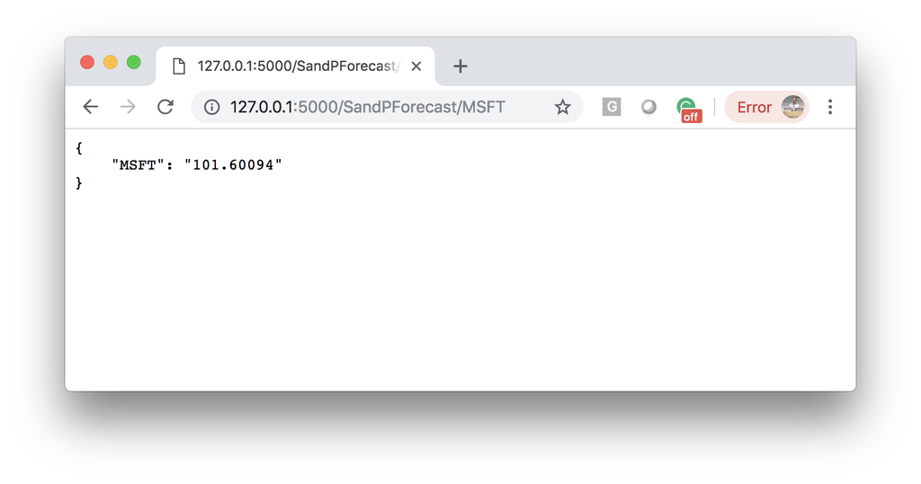

```python
from IPython.display import Image
Image(filename="msft-results.png")
```

Try this in Postman

[figure not shown]

```python
Image(filename="postman-msft-results.png")
```

## Moving our code to PythonAnywhere

First get a free account on [PythonAnywhere](https://www.pythonanywhere.com/) (no credit cards required, only a valid email address) and follow these steps.

### Setting Up Flask Web Framework

Next, create a web server with the Flask web-serving platform. It is super easy to do. Under the 'Web' tab, click the 'Add a new web app' blue button. And accept the defaults until you get to the 'Select a Python Web framework' and click on 'Flask' and then the latest Python framework.

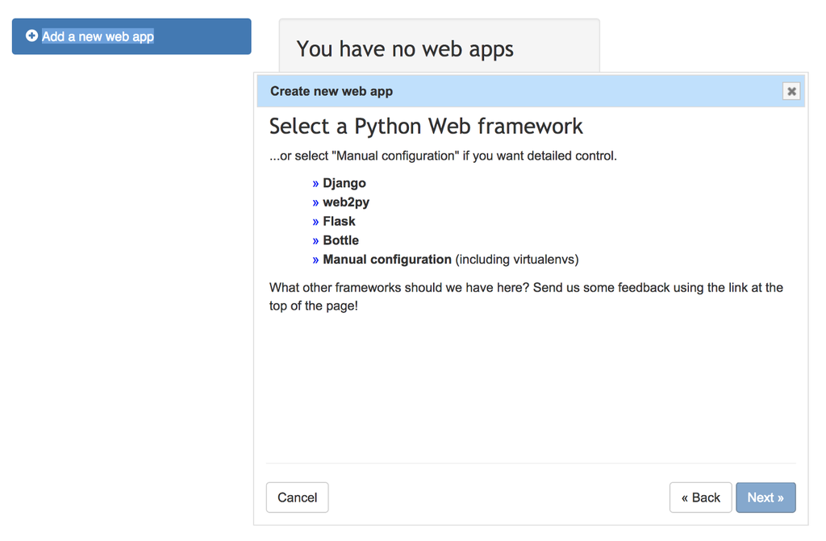

```python
Image(filename="pythonanywhere-framework.png")
```

You will get to the landing configuration page, hit the green 'Reload your account.pythonanywhere.com' button and take your new URL for a spin:

[figure not shown]

```python
Image(filename="pythonanywhere-reload-website.png")
```

You should see a simple but real web page with the 'Hello from Flask!' message:

[figure not shown]

```python
Image(filename="pythonanywhere-hello-from-flask.png")
```

Yep, you're serving server-side web content for free! Now, let's change that silly message with our Rest API stock market prediction service.

### Setting Up Your Web Server

```
stock_market_predictions/
├── main.py
└── stock_model_ready.csv
```

You will have to install a few libraries on PythonAywhere:

```
pip3 install xgboost --user
pip3 install git+https://github.com/pydata/pandas-datareader.git --user
```